# Chapter 10: Advanced Likelihood Methods and Numerical Optimisation

2026-02-25

# 1 Extended Distributions

## 1.1 Gamma Distribution

The **Gamma distribution** $\Gamma(\alpha, \beta)$ is a flexible, continuous distribution for modelling positive-valued data — especially waiting times, rainfall amounts, or insurance claims.

$$f(x \mid \alpha, \beta) =
\frac{x^{\alpha - 1} e^{-x/\beta}}{\beta^\alpha \Gamma(\alpha)}, \quad x
> 0$$

| Parameter | Name | Role |
| --- | --- | --- |
| $\alpha > 0$ | **Shape** | Controls the form of the curve |
| $\beta > 0$ | **Scale** | Stretches or compresses the distribution |

| Property | Value |
| --- | --- |
| Mean | $\alpha\beta$ |
| Variance | $\alpha\beta^2$ |
| Special cases | $\alpha=1$ → Exponential; $\alpha=k/2$, $\beta=2$ → Chi-squared with $k$ df |

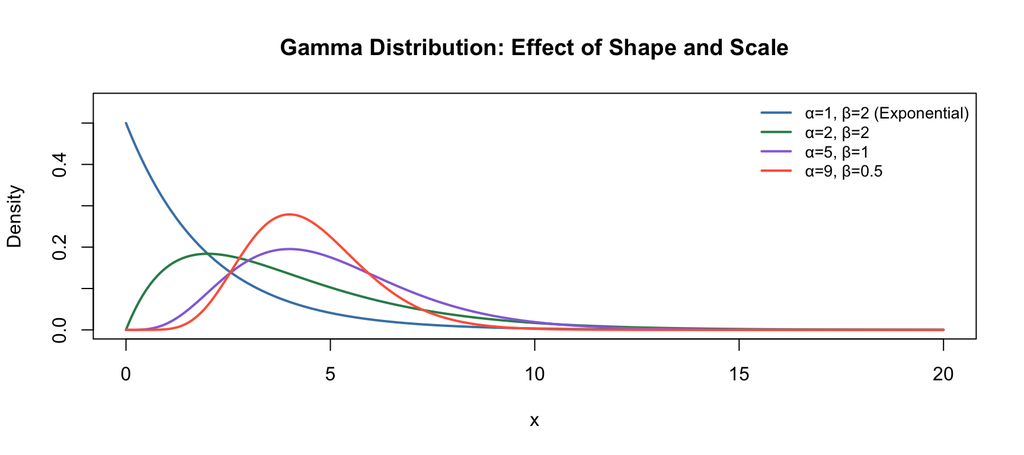

```r
x <- seq(0, 20, length.out = 300)

params <- list(
  list(shape = 1, scale = 2, label = "α=1, β=2 (Exponential)"),
  list(shape = 2, scale = 2, label = "α=2, β=2"),
  list(shape = 5, scale = 1, label = "α=5, β=1"),
  list(shape = 9, scale = 0.5, label = "α=9, β=0.5")
)

colours <- c("steelblue", "seagreen", "mediumpurple", "tomato")

plot(NULL, xlim = c(0, 20), ylim = c(0, 0.55),
     main = "Gamma Distribution: Effect of Shape and Scale",
     xlab = "x", ylab = "Density")

for (i in seq_along(params)) {
  p <- params[[i]]
  lines(x, dgamma(x, shape = p$shape, scale = p$scale),
        col = colours[i], lwd = 2)
}

legend("topright",
       legend = sapply(params, `[[`, "label"),
       col    = colours,
       lwd    = 2, bty = "n", cex = 0.85)
```

# 2 Properties of MLE

## 2.1 Consistency

$$\hat{\theta}_n \xrightarrow{p} \theta
\quad \text{as } n \to \infty$$

As sample size grows, the MLE **converges in probability** to the true parameter. It will not systematically over- or under-estimate for large $n$.

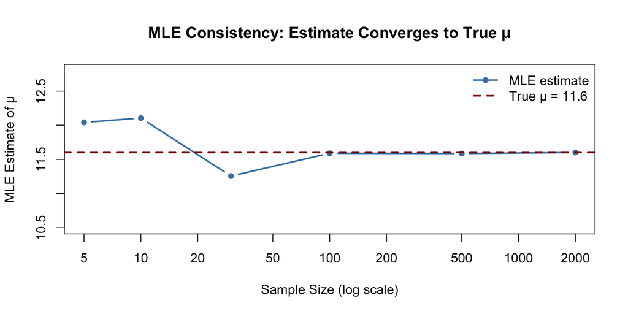

```r
set.seed(42)
true_mu  <- 11.6    # true mean
ns       <- c(5, 10, 30, 100, 500, 2000)
mle_ests <- sapply(ns, function(n) {
  mean(rnorm(n, mean = true_mu, sd = 1))   # MLE for Normal μ = sample mean
})

plot(ns, mle_ests,
     type = "b", pch = 16,
     col  = "steelblue", lwd = 2,
     log  = "x",
     main = "MLE Consistency: Estimate Converges to True μ",
     xlab = "Sample Size (log scale)",
     ylab = "MLE Estimate of μ",
     ylim = c(10.5, 12.8))
abline(h = true_mu, col = "darkred", lwd = 2, lty = 2)
legend("topright",
       legend = c("MLE estimate", paste0("True μ = ", true_mu)),
       col    = c("steelblue", "darkred"),
       lty    = c(1, 2), pch = c(16, NA), lwd = 2, bty = "n")
```

## 2.2 Efficiency

The MLE achieves the **Cramér-Rao lower bound** — no unbiased estimator can have smaller variance asymptotically.

$$\text{Var}(\hat{\theta}) \geq
\frac{1}{\mathcal{I}(\theta)}, \quad \mathcal{I}(\theta) =
-E\!\left[\frac{d^2\ell}{d\theta^2}\right]$$

where $\mathcal{I}(\theta)$ is the **Fisher information**. More information → lower bound → more precise estimate.

## 2.3 Asymptotic Normality

For large $n$, the MLE is approximately normally distributed:

$$\hat{\theta} \;\dot{\sim}\;
\mathcal{N}\!\left(\theta,\;
\frac{1}{n\,\mathcal{I}(\theta)}\right)$$

This justifies using Normal-based confidence intervals for MLEs in large samples and underlies the **Wald test**.

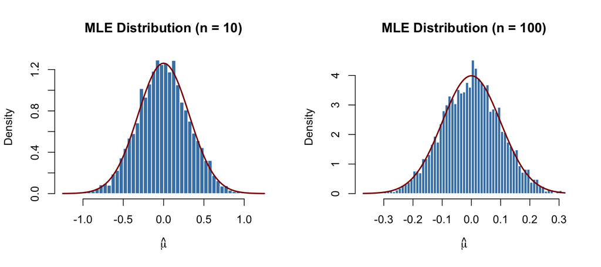

```r
set.seed(42)

n_sims   <- 5000
ns_demo  <- c(10, 100)
par(mfrow = c(1, 2))

for (n in ns_demo) {
  mle_dist <- replicate(n_sims, mean(rnorm(n, mean = 0, sd = 1)))
  hist(mle_dist,
       breaks  = 50,
       col     = "steelblue",
       border  = "white",
       freq    = FALSE,
       main    = paste0("MLE Distribution (n = ", n, ")"),
       xlab    = expression(hat(mu)))
  curve(dnorm(x, mean = 0, sd = 1 / sqrt(n)),
        add = TRUE, col = "darkred", lwd = 2)
}
```

```r
par(mfrow = c(1, 1))
```

# 3 Likelihood-Based Testing

## 3.1 Likelihood Ratio Test (LRT)

The **LRT** formally compares two nested models:

- $M_0$: restricted model (fewer parameters) — log-likelihood $\ell_0$
- $M_1$: full model (more parameters) — log-likelihood $\ell_1$

$$\Lambda = 2\bigl(\ell_1 - \ell_0\bigr)
\;\dot{\sim}\; \chi^2_k \quad \text{under } H_0$$

where $k$ = number of additional parameters in $M_1$.

**Decision rule:** Reject $H_0$ if $\Lambda > \chi^2_{k,\,1-\alpha}$.

```r
# Fit two models via MLE and compare with LRT
# H0: μ = 11 (restricted)
# H1: μ = x̄  (unrestricted, MLE)

mu_restricted   <- 11
mu_mle          <- mean(obs_data)

ll_restricted   <- sum(dnorm(obs_data, mean = mu_restricted, sd = 1, log = TRUE))
ll_full         <- sum(dnorm(obs_data, mean = mu_mle,        sd = 1, log = TRUE))

LRT_stat        <- 2 * (ll_full - ll_restricted)
p_value_lrt     <- pchisq(LRT_stat, df = 1, lower.tail = FALSE)

cat("H0: μ =", mu_restricted, " | MLE: μ̂ =", mu_mle, "\n")
```

```
#> H0: μ = 11  | MLE: μ̂ = 11.6
```

```r
cat("Log-lik (restricted) :", round(ll_restricted, 4), "\n")
```

```
#> Log-lik (restricted) : -8.0947
```

```r
cat("Log-lik (full MLE)   :", round(ll_full, 4), "\n")
```

```
#> Log-lik (full MLE)   : -7.1947
```

```r
cat("LRT statistic (Λ)    :", round(LRT_stat, 4), "\n")
```

```
#> LRT statistic (Λ)    : 1.8
```

```r
cat("p-value              :", round(p_value_lrt, 4), "\n")
```

```
#> p-value              : 0.1797
```

```r
cat("Decision             :", ifelse(p_value_lrt < 0.05,
                                     "Reject H0", "Fail to reject H0"), "\n")
```

```
#> Decision             : Fail to reject H0
```

## 3.2 Profile Likelihood

**Profile likelihood** is used when there are multiple parameters. One parameter of interest $\psi$ is varied; the **nuisance parameters** $\lambda$ are maximised out at each value of $\psi$:

$$\ell_p(\psi) = \max_{\lambda}\;
\ell(\psi, \lambda \mid \mathbf{x})$$

This produces a 1-D curve in $\psi$, regardless of how many other parameters exist, making inference tractable.

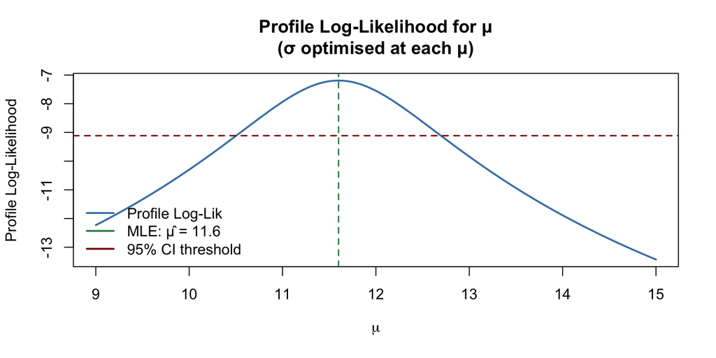

```r
# Profile likelihood for μ (varying μ, estimating σ at each μ)
mu_grid    <- seq(9, 15, length.out = 200)
profile_ll <- numeric(length(mu_grid))

for (i in seq_along(mu_grid)) {
  mu_fixed <- mu_grid[i]
  # Profile out σ: find σ that maximises likelihood at this μ
  opt_sigma <- optimize(
    function(sigma) -sum(dnorm(obs_data, mean = mu_fixed, sd = sigma, log = TRUE)),
    lower = 0.01, upper = 10
  )
  profile_ll[i] <- -opt_sigma$objective
}

plot(mu_grid, profile_ll,
     type = "l", lwd = 2, col = "steelblue",
     main = "Profile Log-Likelihood for μ\n(σ optimised at each μ)",
     xlab = expression(mu),
     ylab = "Profile Log-Likelihood")

# 95% likelihood-based CI: drop by qchisq(0.95,1)/2 ≈ 1.92
ci_threshold <- max(profile_ll) - qchisq(0.95, df = 1) / 2
abline(h = ci_threshold, col = "darkred",  lty = 2, lwd = 1.5)
abline(v = mean(obs_data), col = "seagreen", lty = 2, lwd = 1.5)

legend("bottomleft",
       legend = c("Profile Log-Lik",
                  paste0("MLE: μ̂ = ", mean(obs_data)),
                  "95% CI threshold"),
       col    = c("steelblue", "seagreen", "darkred"),
       lty    = 1, lwd = 2, bty = "n")
```

## 3.3 Likelihood-Based Confidence Intervals

The **likelihood interval** at level $1-\alpha$ is the set of $\theta$ values with relative log-likelihood above a threshold:

$$\left\{\theta :
2\bigl[\ell(\hat{\theta}) - \ell(\theta)\bigr] \leq
\chi^2_{1,\,1-\alpha}\right\}$$

For 95% CI: threshold = $\chi^2_{1, 0.95}/2 \approx 1.92$ log-likelihood units below the maximum.

# 4 Numerical Optimisation Algorithms

When analytical derivatives are unavailable, numerical optimisation finds the MLE iteratively.

## 4.1 Gradient Ascent / Descent

The simplest idea: move in the direction of the gradient by a small step $\eta$ (the **learning rate**):

$$\theta^{(t+1)} = \theta^{(t)} + \eta
\cdot \frac{d\ell}{d\theta}\bigg|_{\theta^{(t)}}$$

- **Gradient ascent** maximises (likelihood).
- **Gradient descent** minimises (loss/negative log-likelihood).

Slow when the gradient is flat; can overshoot when the gradient is steep.

## 4.2 Newton’s Method

Uses both the **gradient** (first derivative) and **curvature** (second derivative) for faster convergence:

$$\theta^{(t+1)} = \theta^{(t)} -
\frac{\ell'(\theta^{(t)})}{\ell''(\theta^{(t)})}$$

Converges **quadratically** near the maximum — much faster than gradient ascent — but requires computing (or approximating) second derivatives.

## 4.3 BFGS

**Broyden–Fletcher–Goldfarb–Shanno (BFGS)** is a *quasi-Newton* method: it approximates the inverse Hessian (second-derivative matrix) iteratively, avoiding expensive exact computation.

## 4.4 Nelder–Mead (Simplex)

A **derivative-free** method that maintains a geometric shape (simplex) in parameter space and iteratively reflects, expands, or contracts it towards the optimum.

- Robust when derivatives are unavailable or unreliable.
- Slower than BFGS; default when no gradient is specified in `optim()`.

| Algorithm | Needs gradient? | Convergence speed | Best for |
| --- | --- | --- | --- |
| Gradient ascent | Yes | Slow | Simple illustration |
| Newton’s method | Yes (+ Hessian) | Very fast | Smooth, low-dim problems |
| BFGS | No (approximates) | Fast | Most smooth MLE problems |
| Nelder-Mead | No | Moderate | Non-smooth or high-dim |

# 5 R Coverage

## 5.1 `optim()` with Multiple Methods

```r
start_val <- 10

# --- BFGS ---
result_bfgs <- optim(par    = start_val,
                     fn     = neg_log_lik,
                     method = "BFGS")

# --- Nelder-Mead ---
result_nm   <- optim(par    = start_val,
                     fn     = neg_log_lik,
                     method = "Nelder-Mead")

cat("True MLE (sample mean):", mean(obs_data), "\n\n")
```

```
#> True MLE (sample mean): 11.6
```

```r
cat("BFGS estimate     :", round(result_bfgs$par, 6),
    "| converged:", result_bfgs$convergence == 0, "\n")
```

```
#> BFGS estimate     : 11.6 | converged: TRUE
```

```r
cat("Nelder-Mead est.  :", round(result_nm$par,   6),
    "| converged:", result_nm$convergence == 0, "\n")
```

```
#> Nelder-Mead est.  : 11.6001 | converged: TRUE
```

## 5.2 Convergence Diagnostics

Always inspect the `optim()` output — a result without convergence is meaningless.

```r
# Run with trace output to watch the optimiser work
result_trace <- optim(par     = 10,
                      fn      = neg_log_lik,
                      method  = "BFGS",
                      control = list(trace = 1, REPORT = 1))
cat("\nConvergence code:", result_trace$convergence,
    "(0 = success)\n")
```

```
#>
#> Convergence code: 0 (0 = success)
```

```r
cat("Final neg-log-lik:", round(result_trace$value, 6), "\n")
```

```
#> Final neg-log-lik: 7.194693
```

```r
cat("MLE estimate     :", round(result_trace$par, 6), "\n")
```

```
#> MLE estimate     : 11.6
```

### 5.2.1 Convergence codes

| Code | Meaning |
| --- | --- |
| `0` | ✅ Successful convergence |
| `1` | Iteration limit reached — increase `maxit` |
| `10` | Degenerate Nelder-Mead simplex |
| `51/52` | Warning from L-BFGS-B — check bounds |

## 5.3 Likelihood Profiling and LRT

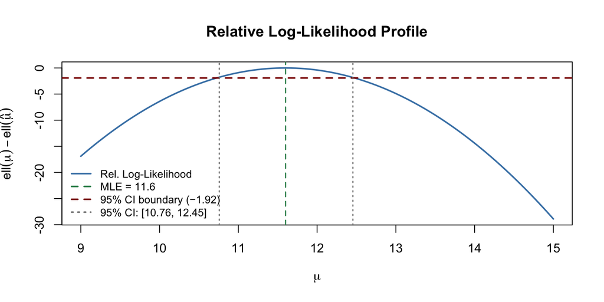

```r
# Likelihood profile across a parameter grid
mu_grid       <- seq(9, 15, length.out = 100)
profile_vals  <- sapply(mu_grid, function(mu) -neg_log_lik(mu))

# Maximum log-likelihood
max_ll        <- max(profile_vals)

# Relative log-likelihood (drop from maximum)
rel_ll        <- profile_vals - max_ll

plot(mu_grid, rel_ll,
     type = "l", lwd = 2, col = "steelblue",
     main = "Relative Log-Likelihood Profile",
     xlab = expression(mu),
     ylab = expression(ell(mu) - ell(hat(mu))))

# 95% CI boundary (Wilks' theorem: drop of qchisq(0.95,1)/2 ≈ 1.92)
ci_drop <- -qchisq(0.95, df = 1) / 2
abline(h = ci_drop, col = "darkred", lty = 2, lwd = 2)
abline(v = mean(obs_data), col = "seagreen", lty = 2, lwd = 1.5)

# Shade the 95% likelihood CI region
ci_region <- mu_grid[rel_ll >= ci_drop]
abline(v = range(ci_region), col = "grey50", lty = 3, lwd = 1.5)

legend("bottomleft",
       legend = c("Rel. Log-Likelihood",
                  paste0("MLE = ", mean(obs_data)),
                  "95% CI boundary (−1.92)",
                  paste0("95% CI: [", round(min(ci_region), 2),
                         ", ", round(max(ci_region), 2), "]")),
       col    = c("steelblue", "seagreen", "darkred", "grey50"),
       lty    = c(1, 2, 2, 3), lwd = 2, bty = "n", cex = 0.85)
```

## 5.4 Multiparameter Optimisation

For problems with two parameters (e.g., estimating both $\mu$ and $\sigma$):

```r
# Negative log-likelihood for Normal with both μ and σ unknown
neg_ll_2param <- function(params) {
  mu    <- params[1]
  sigma <- params[2]
  if (sigma <= 0) return(Inf)    # σ must be positive
  -sum(dnorm(obs_data, mean = mu, sd = sigma, log = TRUE))
}

result_2d <- optim(par    = c(mu = 10, sigma = 2),   # initial guesses
                   fn     = neg_ll_2param,
                   method = "BFGS",
                   hessian = TRUE)    # request Hessian for SEs

cat("MLE μ̂     :", round(result_2d$par["mu"],    4), "\n")
```

```
#> MLE μ̂     : 11.6
```

```r
cat("MLE σ̂     :", round(result_2d$par["sigma"], 4), "\n")
```

```
#> MLE σ̂     : 1.0198
```

```r
cat("True μ    :", mean(obs_data), "\n")
```

```
#> True μ    : 11.6
```

```r
cat("True σ_MLE:", round(sd(obs_data) * sqrt((length(obs_data)-1) /
                           length(obs_data)), 4), "\n")
```

```
#> True σ_MLE: 1.0198
```

```r
# Standard errors from the Hessian (observed Fisher information)
se <- sqrt(diag(solve(result_2d$hessian)))
cat("SE(μ̂)     :", round(se["mu"],    4), "\n")
```

```
#> SE(μ̂)     : 0.4561
```

```r
cat("SE(σ̂)     :", round(se["sigma"], 4), "\n")
```

```
#> SE(σ̂)     : 0.3225
```

> **Hessian → Standard Errors:** The negative Hessian of the log-likelihood evaluated at $\hat{\theta}$ is the **observed Fisher information matrix** $\mathcal{I}(\hat{\theta})$. Its inverse gives the asymptotic covariance matrix of the MLE, so `sqrt(diag(solve(hessian)))` gives the standard errors.

# 6 Chapter Summary

| Concept | Key Takeaway |
| --- | --- |
| Gamma$(\alpha, \beta)$ | Flexible positive-data model; shape $\alpha$, scale $\beta$; includes Exponential and $\chi^2$ as special cases |
| MLE consistency | $\hat{\theta} \to \theta$ as $n \to \infty$ |
| MLE efficiency | Achieves Cramér-Rao lower bound; smallest possible asymptotic variance |
| Asymptotic normality | $\hat{\theta} \approx \mathcal{N}(\theta, 1/n\mathcal{I}(\theta))$ for large $n$ |
| LRT ($\Lambda$) | $2(\ell_1 - \ell_0) \sim \chi^2_k$; compares nested models |
| Profile likelihood | Fix $\psi$, maximise over nuisance params; yields 1-D curve for inference |
| Likelihood CI | $\theta$ values within 1.92 log-likelihood units of $\hat{\theta}$ (95%) |
| Gradient descent | Step in gradient direction; slow but simple |
| Newton’s method | Uses gradient + curvature; fast quadratic convergence |
| BFGS | Quasi-Newton; approximates Hessian; fast and practical |
| Nelder-Mead | Derivative-free simplex; robust but slower |
| R: `optim()` | `method="BFGS"` or `"Nelder-Mead"`; check `convergence == 0` |
| R: `hessian=TRUE` | Returns observed Fisher information → SEs via `sqrt(diag(solve(H)))` |
| Convergence code 0 | ✅ Optimisation succeeded; any other code requires investigation |